# TzeFungLung_FinalExam

jim lung

12-10-2017

# DATA 605 Final Exam

## Dataset

Website: https://www.kaggle.com/c/house-prices-advanced-regression-techniques provides a dataset about 1460 objects of 80 variables that With 79 explanatory variables describing every aspect of residential homes in Ames, Iowa, to predict the final saleprice of each home.

```r
# read in training data, use ID column as row names
train <- read.csv('train.csv', row.names = 1)
head(train)
```

```
##   MSSubClass MSZoning LotFrontage LotArea Street Alley LotShape
## 1         60       RL          65    8450   Pave  <NA>      Reg
## 2         20       RL          80    9600   Pave  <NA>      Reg
## 3         60       RL          68   11250   Pave  <NA>      IR1
## 4         70       RL          60    9550   Pave  <NA>      IR1
## 5         60       RL          84   14260   Pave  <NA>      IR1
## 6         50       RL          85   14115   Pave  <NA>      IR1
##   LandContour Utilities LotConfig LandSlope Neighborhood Condition1
## 1         Lvl    AllPub    Inside       Gtl      CollgCr       Norm
## 2         Lvl    AllPub       FR2       Gtl      Veenker      Feedr
## 3         Lvl    AllPub    Inside       Gtl      CollgCr       Norm
## 4         Lvl    AllPub    Corner       Gtl      Crawfor       Norm
## 5         Lvl    AllPub       FR2       Gtl      NoRidge       Norm
## 6         Lvl    AllPub    Inside       Gtl      Mitchel       Norm
##   Condition2 BldgType HouseStyle OverallQual OverallCond YearBuilt
```

[output cut: 76 more lines]

Final sale price (in dollars) is defined as the dependent variable $Y$ and the above grade living area (in square feet) is defined as the independent variable $X$.

```r
# Choose my quantitative independent variable to be Overall Quality
X <- train$GrLivArea

# Choose Sale Price as my dependent variable as per the Kaggle Competition
Y <- train$SalePrice

# Let's get the median and mean to show it is skewed to the right
summary(X)
```

```
##    Min. 1st Qu.  Median    Mean 3rd Qu.    Max.
##     334    1130    1464    1515    1777    5642
```

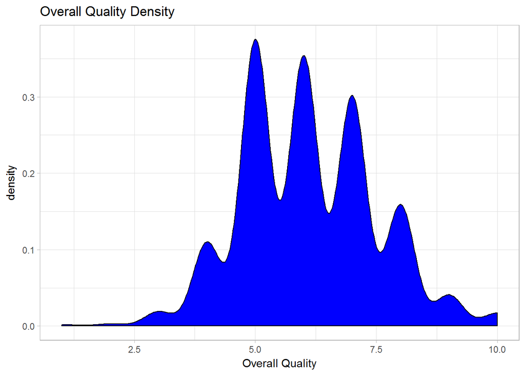

```r
library(ggplot2)
# Plot Overall Quality to visually show it is skewed to the right
ggplot(data = train) + geom_density(aes(x=OverallQual), fill="blue") + labs(x="Overall Quality") + ggtitle("Overall Quality Density") + theme_light()
```

```r
# We have the quartiles for X above, here we get them for Y
summary(Y)
```

```
##    Min. 1st Qu.  Median    Mean 3rd Qu.    Max.
##   34900  130000  163000  180900  214000  755000
```

“x” is estimated as the 1d quartile of the X variable: x = 1130

“y” is estimated as the 2d quartile of the Y variable: y = 163,000

```r
# we count the number of rows with SalesPrice > 163,000
sum(Y > 163000)
```

```
## [1] 728
```

```r
# Total number of rows
length(Y)
```

```
## [1] 1460
```

```r
length(X)
```

```
## [1] 1460
```

```r
# Rows where both Y > y and X > x
sum(Y > 163000 & X > 1130)
```

```
## [1] 720
```

```r
Q1x <- quantile(X,0.25)
Q1x
```

```
##    25%
## 1129.5
```

```r
Q2y <- quantile(Y,0.5)
Q2y
```

```
##    50%
## 163000
```

### a) P(X > x | Y > y)

```r
# The probability P(X>x | Y>y)
(sum(Y > Q2y & X > Q1x) / length(X)) / (sum(Y > Q2y) / length(Y))
```

```
## [1] 0.989011
```

### b) P(X > x, Y > y)

```r
# The probability P(X>x and Y>y)
sum(X > Q1x & Y > Q2y) / length(X)
```

```
## [1] 0.4931507
```

### c) P(X < x | Y > y)

```r
# The probability P(X<x | Y>y)
(sum(Y > Q2y & X < Q1x) / length(X)) / (sum(Y > Q2y) / length(Y))
```

```
## [1] 0.01098901
```

## P(X|Y)=P(X)P(Y)

Does splitting the training data in this fashion make them independent? In other words, does P(X|Y)=P(X)P(Y))? Check mathematically, and then evaluate by running a Chi Square test for association. You might have to research this.

### mathematical method

```r
# P(x) = P(above the 1d quartile for X)
px <- sum(X > Q1x) / length(X)
px
```

```
## [1] 0.75
```

```r
# P(Y) = P(above the 2d quartile for Y)
py <- sum(Y > Q2y) / length(Y)
py
```

```
## [1] 0.4986301
```

```r
# P(x)*P(Y)
pxy <- px*py
pxy
```

```
## [1] 0.3739726
```

```r
# P(X|Y) = P(Y and X) / P(Y)
pxxyy <- (sum(X > Q1x & Y > Q2y) / length(X)) / py
pxxyy
```

```
## [1] 0.989011
```

$P(A | B) \ne P(A) P(B)$, which implies that my variables are not independent, so splitting the data in this fashion does not make them independent.

### Chi Square test

The Chi Square Test, tests the hypothesis of whether the grade living area (in square feet) is independent of the Sale Price. We could debate a 5% to 1% significance level, but in this case that’s not necessary. With a p-value of well under 1% we reject the null hypothesis that the grade living area (in square feet) is independent of the Sale Price of a house.

```r
if (!require(MASS)) install.packages("MASS")
library(MASS)

tbl <- table(train$GrLivArea > Q1x, train$SalePrice > Q2y)
chisq.test(tbl)
```

```
##
##  Pearson's Chi-squared test with Yates' continuity correction
##
## data:  tbl
## X-squared = 439.85, df = 1, p-value < 2.2e-16
```

## Descriptive and Inferential Statistics.

Provide univariate descriptive statistics and appropriate plots for both variables. Provide a scatterplot of X and Y. Transform both variables simultaneously using Box-Cox transformations. You might have to research this.

### Dataset

Summary statistics for $X$ and $Y$ are provided in the table below:

```r
library(pander)
# prepare summary table supplemented with standard deviation
sum_tbl <- rbind(c(summary(X), 'Std. Dev.'=round(sd(X), 0)),
                 c(summary(Y), 'Std. Dev.'=round(sd(Y), 0)))
row.names(sum_tbl) <- c('X', 'Y')
pander(sum_tbl)
```

|  | Min. | 1st Qu. | Median | Mean | 3rd Qu. | Max. | Std. Dev. |
| --- | --- | --- | --- | --- | --- | --- | --- |
| **X** | 334 | 1130 | 1464 | 1515 | 1777 | 5642 | 525 |
| **Y** | 34900 | 130000 | 163000 | 180900 | 214000 | 755000 | 79443 |

The plots below show the joint distributions of the two variables

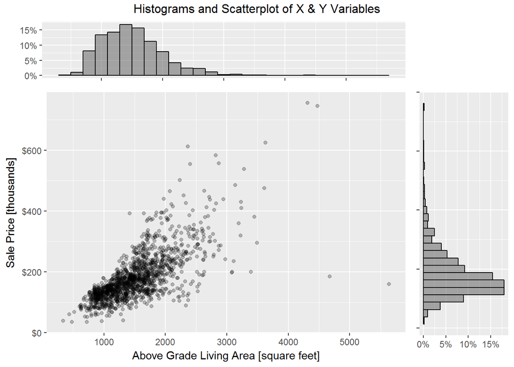

```r
library(ggplot2)
library(scales)
# scatter of X & Y
pscat <- ggplot(data.frame(X, Y), aes(X, Y / 1000)) +
  geom_point(alpha = 0.25) +
  scale_x_continuous('Above Grade Living Area [square feet]') +
  scale_y_continuous('Sale Price [thousands]', labels = dollar)
# histogram of X
px <- ggplot(data.frame(X), aes(X, ..count.. / sum(..count..))) +
  geom_histogram(alpha = 0.5, col = 'black', binwidth = 200) +
  scale_x_continuous(name = NULL, labels = NULL) +
  scale_y_continuous(name = '', labels = percent)
# histogram of Y
py <- ggplot(data.frame(Y), aes(Y, ..count.. / sum(..count..))) +
  geom_histogram(alpha = 0.5, col = 'black', binwidth = 25000) +
  scale_x_continuous(name = NULL, labels = NULL) +
  scale_y_continuous(name = '', labels = percent) +
  coord_flip()

# combined plots
library(grid)
library(gridExtra)
grid.arrange(px, rectGrob(NA), pscat, py,
             nrow=2, widths = c(0.8, 0.2), heights = c(0.2, 0.8),
             top = 'Histograms and Scatterplot of X & Y Variables')
```

### Scatterplot X and Y

Below is a scatterplot of grade living area (in square feet) versus Sale Price. I overlayed the regression line and the lighter band around the line is the 95% confidence interval.

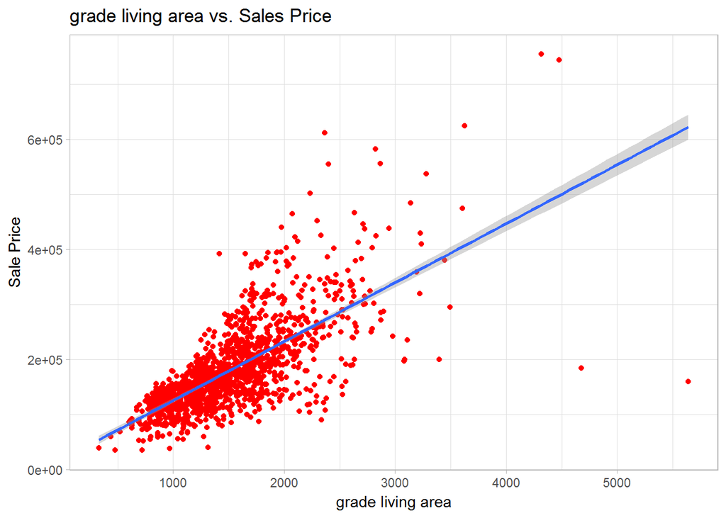

```r
# Plot Overall Quality versus Sales Price and overlay a regression line
ggplot(train, aes(x = GrLivArea, y = SalePrice)) + geom_point(color="red") + labs(x="grade living area", y = "Sale Price") + ggtitle("grade living area vs. Sales Price") + geom_smooth(method = "lm", se = TRUE) + theme_light()
```

### 95% Confidence Interval

Provide a 95% CI for the difference in the mean of the variables.

We show below a 95% confidence that the difference in the means of x and y will be between 175.3K and 183.5K

```r
# Run the T test
t.test(Y, X)
```

```
##
##  Welch Two Sample t-test
##
## data:  Y and X
## t = 86.288, df = 1459.1, p-value < 2.2e-16
## alternative hypothesis: true difference in means is not equal to 0
## 95 percent confidence interval:
##  175327.3 183484.2
## sample estimates:
##  mean of x  mean of y
## 180921.196   1515.464
```

```r
# The assumption for the test is that both groups are sampled from normal distributions with equal variances
diffmean <- t.test(X, Y, paired = TRUE)$conf.int
diffmean
```

```
## [1] -183465.0 -175346.4
## attr(,"conf.level")
## [1] 0.95
```

### Correlation Matrix

Derive a correlation matrix for two of the quantitative variables you selected. Test the hypothesis that the correlation between these variables is 0 and provide a 99% confidence interval.

```r
# Setup and run correlation test
data <- data.frame(X, Y)
cm <- cor(data)
cm
```

```
##           X         Y
## X 1.0000000 0.7086245
## Y 0.7086245 1.0000000
```

```r
cor.test(Y, X, conf.level = 0.99)
```

```
##
##  Pearson's product-moment correlation
##
## data:  Y and X
## t = 38.348, df = 1458, p-value < 2.2e-16
## alternative hypothesis: true correlation is not equal to 0
## 99 percent confidence interval:
##  0.6733974 0.7406408
## sample estimates:
##       cor
## 0.7086245
```

### Analysis

The Pearson correlation is 0.7086. The Pearson correlation coefficient can take a range of values from +1 to -1. A value of 0 indicates that there is no association between the two variables. A value greater than 0 indicates a positive association; that is, as the value of one variable increases, so does the value of the other variable. This test result is a strong indication of a correlation between grade living area and Sale Price.

## Linear Algebra and Correlation

Using at least three untransformed variables, build a correlation matrix. Invert your correlation matrix. (This is known as the precision matrix and contains variance inflation factors on the diagonal.) Multiply the correlation matrix by the precision matrix, and then multiply the precision matrix by the correlation matrix.

Assuming our square correlation matrix is invertible, the process outlined above should create the identity matrix due to $AA^{-1} = A^{-1}A = I$

```r
# Correlaiton Matrix
cm
```

```
##           X         Y
## X 1.0000000 0.7086245
## Y 0.7086245 1.0000000
```

```r
# #Invert Correlaiton Matrix
pm <- solve(cm)
pm
```

```
##           X         Y
## X  2.008632 -1.423366
## Y -1.423366  2.008632
```

```r
# Multiply the correlation matrix by the precision matrix# Multiply the correlation matrix by the precision matrix
#A*A^-1
AAn1 <- cm%*%pm
AAn1
```

```
##   X Y
## X 1 0
## Y 0 1
```

```r
# Multiply the precision matrix by the correlation matrix
#A^-1*A
An1A <- pm %*% cm
An1A
```

```
##   X Y
## X 1 0
## Y 0 1
```

## Calculus-Based Probability & Statistics

Many times, it makes sense to fit a closed form distribution to data. For your non-transformed independent variable, location shift (if necessary) it so that the minimum value is above zero. Then load the MASS package and run fitdistr to fit a density function of your choice.

### Probability

Find the optimal value of λλ for this distribution, and then take 1000 samples from this exponential distribution using this value (e.g., rexp(1000, λλ)). Plot a histogram and compare it with a histogram of your original variable.

```r
# Run fitdistr to fit an exponential probability density function
ep <- fitdistr(train$GrLivArea, "exponential")
ep
```

```
##        rate
##   6.598640e-04
##  (1.726943e-05)
```

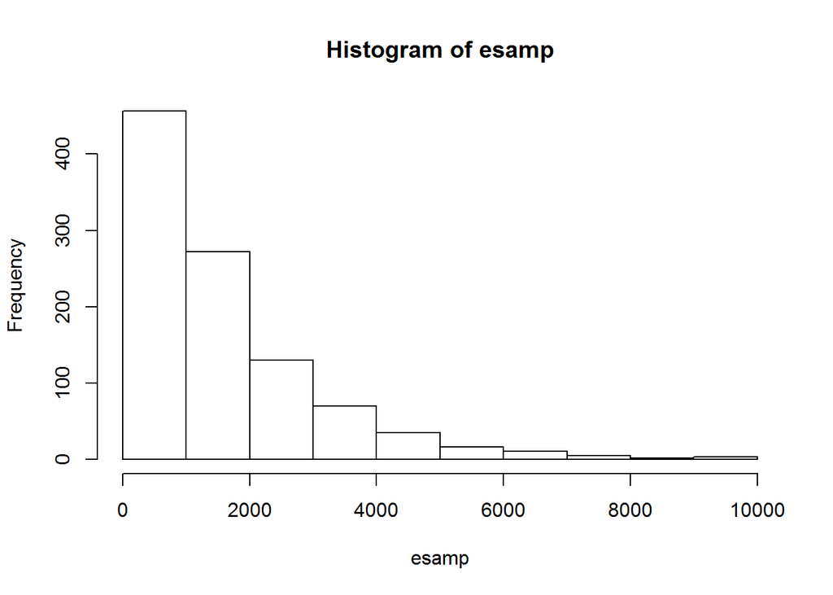

```r
# Take 1000 samples from the exponential distribution, set.seed is so percentiles below stay the same
set.seed(1)
esamp <- rexp(1000, 6.598640e-04)

# Plot a histogram and compare it with a histogram of your original variable
hist(esamp)
```

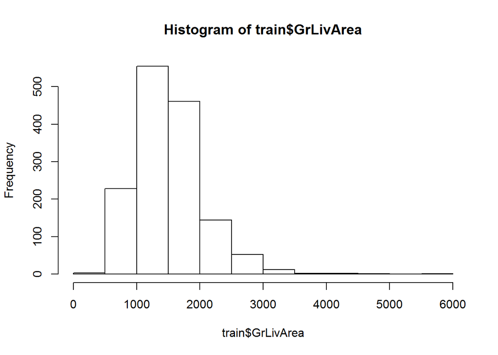

```r
hist(train$GrLivArea)
```

### Exponential PDF Percentiles

using the cumulative distribution function (CDF) to find the 5th and 95th percentiles:

```r
quantile(esamp, probs=c(.05,.95))
```

```
##         5%        95%
##   78.87384 4481.40505
```

lower or left side of the interval:

```r
# The lower or left side of the interval for GrLivArea = mean - error
mean(train$GrLivArea) - qnorm(0.95) * sd(train$GrLivArea) / sqrt(length(train$GrLivArea))
```

```
## [1] 1492.843
```

```r
# The upper or right side of the interval for GrLivArea = mean + error
mean(train$GrLivArea) + qnorm(0.95) * sd(train$GrLivArea) / sqrt(length(train$GrLivArea))
```

```
## [1] 1538.084
```

```r
# Find the empirical 5th percentile and 95th percentile of the data
quantile(train$GrLivArea, probs=c(.05,.95))
```

```
##     5%    95%
##  848.0 2466.1
```

5th percentile is 848 and 95th percentile is 2466.

## Modeling

In order to predict the sale price of houses using information about the characteristics of a house, regression models are constructed and their results entered into the Kaggle competition.

### Bayesian Information Criterion

The model considers only the numeric variables examined in previous section. The `leaps` package is utilized to determine the minimum Bayesian Information Criterion (BIC) to select the best model as shown below.

```r
library(dplyr)
# first variable is categorical values stored by numeric key; convert to factor
train$MSSubClass <- factor(train$MSSubClass)
# impute LotFrontage and MasVnrArea with zero
train$LotFrontage[is.na(train$LotFrontage)] <- 0
train$MasVnrArea[is.na(train$MasVnrArea)] <- 0
# impute GarageYrBlt with delta between YearBuilt
train$GarageYrBlt[is.na(train$GarageYrBlt)] <-
  train$YearBuilt[is.na(train$GarageYrBlt)] +
  median(train$GarageYrBlt - train$YearBuilt, na.rm = TRUE)
# gather all explanatory variables and exclude non-numeric variables

pca_data <- train[, sapply(train, is.numeric)] %>% select(-SalePrice)
```

[output not shown]

[output not shown]

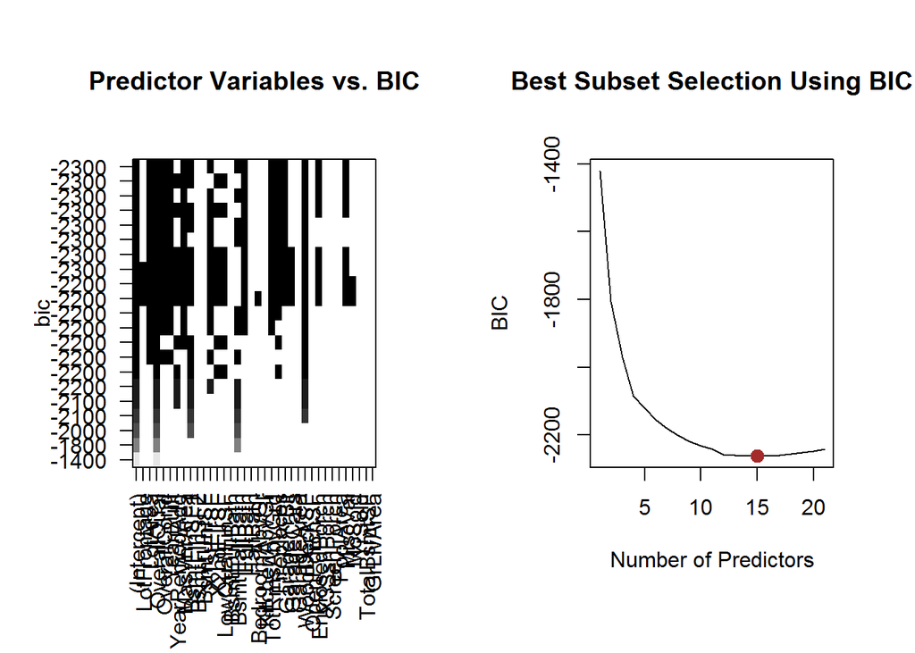

```r
reg.summary <- summary(regfit)
# plot variables vs BIC & BIC vs # variables
par(mfrow = c(1, 2), mar=c(1,1,1,1))
plot(regfit, scale = "bic", main = "Predictor Variables vs. BIC")
plot(reg.summary$bic, xlab = "Number of Predictors", ylab = "BIC",
     type = "l", main = "Best Subset Selection Using BIC")
# annotate lowest BIC
minbic <- which.min(reg.summary$bic)
points(minbic, reg.summary$bic[minbic], col = "brown", cex = 2, pch = 20)
```

The parameters of this model are presented below:

```r
# get formula using 15 criteria
usedvars = names(coef(regfit, minbic))[-1]
BIC_model = paste0("glm(SalePrice ~ ", paste(usedvars, collapse = " + "),
                   ", data = model_data)")
# run model and print summary
bestsubset = eval(parse(text = BIC_model))
# print model summary
pander(summary(bestsubset))
```

|  | Estimate | Std. Error | t value | Pr(>\|t\|) |
| --- | --- | --- | --- | --- |
| **(Intercept)** | -1066852 | 113116 | -9.431 | 1.553e-20 |
| **LotArea** | 0.6162 | 0.1077 | 5.721 | 1.286e-08 |
| **OverallQual** | 24431 | 1123 | 21.75 | 5.986e-91 |
| **OverallCond** | 5557 | 1007 | 5.517 | 4.085e-08 |
| **YearBuilt** | 273.4 | 71.76 | 3.81 | 0.0001446 |
| **MasVnrArea** | 39.46 | 6.257 | 6.307 | 3.779e-10 |
| **BsmtFinSF1** | 19.94 | 2.592 | 7.692 | 2.657e-14 |
| **X1stFlrSF** | 26.85 | 3.475 | 7.726 | 2.06e-14 |
| **BsmtHalfBath** | -4250 | 4211 | -1.009 | 0.313 |
| **FullBath** | 6379 | 2583 | 2.47 | 0.01363 |
| **TotRmsAbvGrd** | 8901 | 828.8 | 10.74 | 6.092e-26 |
| **Fireplaces** | 8832 | 1820 | 4.853 | 1.346e-06 |
| **GarageYrBlt** | 203.1 | 72.73 | 2.792 | 0.005306 |
| **WoodDeckSF** | 32.95 | 8.486 | 3.883 | 0.000108 |
| **EnclosedPorch** | 25.93 | 17.95 | 1.445 | 0.1488 |
| **MiscVal** | -1.491 | 2.008 | -0.7423 | 0.458 |

(Dispersion parameter for gaussian family taken to be 1432794491 )

| Null deviance: | 9.208e+12 on 1459 degrees of freedom |
| --- | --- |
| Residual deviance: | 2.069e+12 on 1444 degrees of freedom |

```r
# read in test data, using ID column as row names
test <- read.csv('test.csv', row.names = 1)

# apply same imputations to test data as train data
test$MSSubClass <- factor(test$MSSubClass)
test$LotFrontage[is.na(test$LotFrontage)] <- 0
test$MasVnrArea[is.na(test$MasVnrArea)] <- 0
test$GarageYrBlt[is.na(test$GarageYrBlt)] <-
  test$YearBuilt[is.na(test$GarageYrBlt)] +
  median(test$GarageYrBlt - test$YearBuilt, na.rm = TRUE)
head(test)
```

```
##      MSSubClass MSZoning LotFrontage LotArea Street Alley LotShape
## 1461         20       RH          80   11622   Pave  <NA>      Reg
## 1462         20       RL          81   14267   Pave  <NA>      IR1
## 1463         60       RL          74   13830   Pave  <NA>      IR1
## 1464         60       RL          78    9978   Pave  <NA>      IR1
## 1465        120       RL          43    5005   Pave  <NA>      IR1
## 1466         60       RL          75   10000   Pave  <NA>      IR1
##      LandContour Utilities LotConfig LandSlope Neighborhood Condition1
## 1461         Lvl    AllPub    Inside       Gtl        NAmes      Feedr
## 1462         Lvl    AllPub    Corner       Gtl        NAmes       Norm
## 1463         Lvl    AllPub    Inside       Gtl      Gilbert       Norm
## 1464         Lvl    AllPub    Inside       Gtl      Gilbert       Norm
## 1465         HLS    AllPub    Inside       Gtl      StoneBr       Norm
## 1466         Lvl    AllPub    Corner       Gtl      Gilbert       Norm
##      Condition2 BldgType HouseStyle OverallQual OverallCond YearBuilt
```

[output cut: 76 more lines]

### predication

```r
# apply models to test dataset
pred_bic = predict(bestsubset, test)

# impute median for NAs
pred_bic[is.na(pred_bic)] <- median(train$SalePrice)

# shift values so all are positive
pred_bic <- pred_bic - min(pred_bic)

# store as data frames
pred_bic <- data.frame(Id = names(pred_bic), SalePrice = pred_bic)
```

```r
# store results
write.csv(pred_bic, 'jimlungBIC.csv', row.names = FALSE)
```